# Self-Driving Car Engineer Nanodegree

## Project: Build a Traffic Sign Recognition Classifier

## Step 0: Load The Data

#### The original data provided as "traffic-signs-data.zip" must be unziped and stored in the subfolder "data"

```python
# necessary imports
import pickle
import pandas as pd
import random
import numpy as np
import os
import tensorflow as tf
import time
import skimage.transform as imgtf
import skimage.exposure as imgexp
import skimage.filters as imgfilt
import scipy.misc
from scipy import ndimage
from numpy import newaxis
import matplotlib.image as mpimg
from sklearn.utils import shuffle
import matplotlib.pyplot as plt
%matplotlib inline
plt.rcParams['image.cmap'] = 'gray'
```

```python
# define some usefull folders
training_file = "data\\train.p"
validation_file= "data\\valid.p"
testing_file = "data\\test.p"

checkpnt_save_path = 'checkpoints/'
plot_save_path = 'plots/'
web_img_path = 'web_img/'

# ensure, that rweb_img_path equired output folder exist
if not os.path.exists(checkpnt_save_path):
    os.makedirs(checkpnt_save_path)
if not os.path.exists(plot_save_path):
    os.makedirs(plot_save_path)
```

```python
# load fetures and labels from pickle file
def load_data_from_pickle(file_name):
    with open(file_name, mode='rb') as f:
        data = pickle.load(f)
        return data['features'], data['labels']

# save fetures and labels from pickle file
def save_data_to_pickle(file_name, x, y):
    with open(file_name, mode='wb') as f:
        data = {"features": x, "labels": y}
        pickle.dump(data, f)
    return

# dump images into directory
def dump_images(file_directory, images, classes):
    for i in range(images.shape[0]):
        imgdir = "{}/{}".format(file_directory, classes[i])
        if not os.path.exists(imgdir):
            os.makedirs(imgdir)
        scipy.misc.imsave("{}/{}.jpg".format(imgdir, i), images[i])
```

```python
# Load pickled data
x_train, y_train = load_data_from_pickle(training_file)
x_valid, y_valid = load_data_from_pickle(validation_file)
x_test, y_test = load_data_from_pickle(testing_file)
```

## Step 1: Dataset Summary & Exploration

The pickled data is a dictionary with 4 key/value pairs:

- `'features'` is a 4D array containing raw pixel data of the traffic sign images, (num examples, width, height, channels).
- `'labels'` is a 1D array containing the label/class id of the traffic sign. The file `signnames.csv` contains id -> name mappings for each id.
- `'sizes'` is a list containing tuples, (width, height) representing the original width and height the image.
- `'coords'` is a list containing tuples, (x1, y1, x2, y2) representing coordinates of a bounding box around the sign in the image. **THESE COORDINATES ASSUME THE ORIGINAL IMAGE. THE PICKLED DATA CONTAINS RESIZED VERSIONS (32 by 32) OF THESE IMAGES**

```python
# Number of training examples
n_train = x_train.shape[0]

# Number of validation examples
n_validation = x_valid.shape[0]

# Number of testing examples.
n_test = x_test.shape[0]

# What's the shape of an traffic sign image?
image_shape = x_train[0].shape

# How many unique classes/labels there are in the dataset.
n_classes = np.unique(y_train).size

# extract names of signs (class names)
class_names = pd.read_csv("signnames.csv").as_matrix()

print("Number of training examples =", n_train)
print("Number of testing examples =", n_test)
print("Image data shape =", image_shape)
print("Number of classes =", n_classes)
```

```
Number of training examples = 34799
Number of testing examples = 12630
Image data shape = (32, 32, 3)
Number of classes = 43
```

### Exploratory visualization of the dataset

```python
### shows bar chart
def show_bar_chart(test_x, test_y, x_label, y_label, title):
    plt.bar(test_x, test_y)
    plt.grid()
    plt.title(title)
    plt.xlabel(x_label)
    plt.ylabel(y_label)
   # plt.show()
    path_to_plot = os.path.join(plot_save_path, title)
    plt.savefig(path_to_plot)
    return
```

```python
### shows bar chart for particular data
def show_bar_chart_of_sign_data(data, title):
    unique_data, data_cnt = np.unique(data, return_counts=True)
    show_bar_chart(unique_data, data_cnt, "Sign labels/classes", "Nr of signs", title)
    return
```

```python
def select_image_samples_for_every_class(images, labels, classes, sample_size=5):
    samples = []
    for c in classes:
        c_labels = np.where(labels == c[0])[0]
        if c_labels.shape[0] > 0:
            selection = images[np.random.choice(c_labels, sample_size)]
            samples.append(selection)
    return np.array(samples)

def plot_image_samples(names, samples):
    n_samples = len(samples[0])
    n_names = len(names)
    for i in range(n_names):
        print(names[i][1])
        fig, axes = plt.subplots(nrows=1, ncols=n_samples, figsize=(n_samples, 1))
        fig.subplots_adjust(hspace = 0.1, wspace = 0.1)
        for j in range(n_samples):
            if n_samples == 1:
                ax = axes
            else:
                ax = axes[j]
            ax.tick_params(bottom='off', top='off', left='off', right='off', labelbottom='off', labeltop='off', labelleft='off', labelright='off')
            ax.imshow(samples[i][j])
        plt.show()
        print()
    return
```

```python
### Data exploration visualization code goes here.
### Feel free to use as many code cells as needed.

# create image samples for every class & plot them
samples_train_before = select_image_samples_for_every_class(x_train, y_train, class_names, 3)
plot_image_samples(class_names, samples_train_before)
```

[output not shown]

```
Speed limit (20km/h)
```

```
Speed limit (30km/h)
```

```
Speed limit (50km/h)
```

```
Speed limit (60km/h)
```

```
Speed limit (70km/h)
```

```
Speed limit (80km/h)
```

```
End of speed limit (80km/h)
```

```
Speed limit (100km/h)
```

```
Speed limit (120km/h)
```

```
No passing
```

```
No passing for vehicles over 3.5 metric tons
```

```
Right-of-way at the next intersection
```

```
Priority road
```

```
Yield
```

```
Stop
```

```
No vehicles
```

```
Vehicles over 3.5 metric tons prohibited
```

```
No entry
```

```
General caution
```

```
Dangerous curve to the left
```

```
Dangerous curve to the right
```

```
Double curve
```

```
Bumpy road
```

```
Slippery road
```

```
Road narrows on the right
```

```
Road work
```

```
Traffic signals
```

```
Pedestrians
```

```
Children crossing
```

```
Bicycles crossing
```

```
Beware of ice/snow
```

```
Wild animals crossing
```

```
End of all speed and passing limits
```

```
Turn right ahead
```

```
Turn left ahead
```

```
Ahead only
```

```
Go straight or right
```

```
Go straight or left
```

```
Keep right
```

```
Keep left
```

```
Roundabout mandatory
```

```
End of no passing
```

```
End of no passing by vehicles over 3.5 metric tons
```

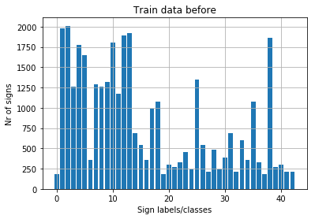

```python
# show statictistic of data
show_bar_chart_of_sign_data(y_train, "Train data before")
```

### Set of functions used to create faked data.

The faked data are created in create_fake_data function thereby stored in coresponding picle and as set of jpg files stored "faked_data_jpg" folder.

```python
# rotate right by random angle
def rotate_right(image):
    angle = random.randint(10, 20)
    image = imgtf.rotate(image, angle, mode='wrap', preserve_range=True)
    return np.clip(image, 0, 255).astype(np.uint8)

# rotate left by random angle
def rotate_left(image):
    angle = -random.randint(10, 20)
    image = imgtf.rotate(image, angle, mode='wrap', preserve_range=True)
    return np.clip(image, 0, 255).astype(np.uint8)

# scale up by random factor
def entlarge (image):
    scale_x = random.uniform(0.80, 0.90)
    scale_y = scale_x
    c = (image.shape[0] / 2 * (1 - scale_x), image.shape[1] / 2 * (1 - scale_y))
    transform = imgtf.AffineTransform(scale=(scale_x, scale_y), translation=c)
    image = imgtf.warp(image, transform, mode='wrap', preserve_range=True)
    return np.clip(image, 0, 255).astype(np.uint8)

# scale down by random factor
def lessen (image):
    scale_x = random.uniform(1.15, 1.25)
    scale_y = scale_x
    c = (image.shape[0] / 2 * (1 - scale_x), image.shape[1] / 2 * (1 - scale_y))
    transform = imgtf.AffineTransform(scale=(scale_x, scale_y), translation=c)
    image = imgtf.warp(image, transform, mode='wrap', preserve_range=True)
    return np.clip(image, 0, 255).astype(np.uint8)

def blur(image):
    sigma = random.uniform(0.75, 1.0)
    image = imgfilt.gaussian(image, sigma=sigma, multichannel=True) * 255
    return np.clip(image, 0, 255).astype(np.uint8)
```

```python
# functionality to created faked data that will help by training process
def create_fake_train_data(features, labels):

    image_op = {0: rotate_right,
            1: rotate_left,
            2: lessen,
            3: entlarge,
            4: blur
            }

    labels_dummy, uniques_count = np.unique(labels, return_counts=True)
    max_uniques_count = np.max(uniques_count)

    print("Create fake data..")
    features_ext = []
    labels_ext = []

    for i in range(features.shape[0]):
        label_id = labels[i]
        # nr of images having this label id
        num_images = uniques_count[label_id]
        num_to_generate = max_uniques_count - num_images
        num_operations = num_to_generate // num_images

        if num_operations > 0:
            selection = np.random.choice([0, 1, 2, 3, 4], num_operations)
            for operation in selection:
                original_img = features[i]
                features_ext.append(image_op[operation](original_img))
                labels_ext.append(label_id)

    features_ext = np.array(features_ext)
    labels_ext = np.array(labels_ext)

    return features_ext, labels_ext


# create or load already cretaed faked data
def create_fake_data(file_name, features, labels):
    if os.path.isfile(file_name):
        print("Loading..")
        features_ext, labels_ext = load_data_from_pickle(file_name)
    else:
        print("Create faked data..")
        features_ext, labels_ext = create_fake_train_data(features, labels)
        save_data_to_pickle(file_name, features_ext, labels_ext)
        dump_images("faked_data_jpg", features_ext, labels_ext)
    return features_ext, labels_ext
```

```python
# create faked data and add them to the original data
x_train_faked, y_train_faked = create_fake_data("data/fake_data.p", x_train, y_train)
x_train = np.concatenate((x_train, x_train_faked))
y_train = np.concatenate((y_train, y_train_faked))

# create image samples for every class & plot them
samples_train_after = select_image_samples_for_every_class(x_train, y_train, class_names, 3)
plot_image_samples(class_names, samples_train_after)
```

[output not shown]

```
Loading..
Speed limit (20km/h)
```

```
Speed limit (30km/h)
```

```
Speed limit (50km/h)
```

```
Speed limit (60km/h)
```

```
Speed limit (70km/h)
```

```
Speed limit (80km/h)
```

```
End of speed limit (80km/h)
```

```
Speed limit (100km/h)
```

```
Speed limit (120km/h)
```

```
No passing
```

```
No passing for vehicles over 3.5 metric tons
```

```
Right-of-way at the next intersection
```

```
Priority road
```

```
Yield
```

```
Stop
```

```
No vehicles
```

```
Vehicles over 3.5 metric tons prohibited
```

```
No entry
```

```
General caution
```

```
Dangerous curve to the left
```

```
Dangerous curve to the right
```

```
Double curve
```

```
Bumpy road
```

```
Slippery road
```

```
Road narrows on the right
```

```
Road work
```

```
Traffic signals
```

```
Pedestrians
```

```
Children crossing
```

```
Bicycles crossing
```

```
Beware of ice/snow
```

```
Wild animals crossing
```

```
End of all speed and passing limits
```

```
Turn right ahead
```

```
Turn left ahead
```

```
Ahead only
```

```
Go straight or right
```

```
Go straight or left
```

```
Keep right
```

```
Keep left
```

```
Roundabout mandatory
```

```
End of no passing
```

```
End of no passing by vehicles over 3.5 metric tons
```

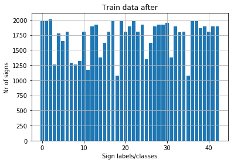

```python
# show statictistic of data
show_bar_chart_of_sign_data(y_train, "Train data after")
```

## Step 2: Design and Test a Model Architecture

Design and implement a deep learning model that learns to recognize traffic signs. Train and test your model on the [German Traffic Sign Dataset](http://benchmark.ini.rub.de/?section=gtsrb&subsection=dataset).

The LeNet-5 implementation shown in the classroom at the end of the CNN lesson is a solid starting point. You'll have to change the number of classes and possibly the preprocessing, but aside from that it's plug and play!

With the LeNet-5 solution from the lecture, you should expect a validation set accuracy of about 0.89. To meet specifications, the validation set accuracy will need to be at least 0.93. It is possible to get an even higher accuracy, but 0.93 is the minimum for a successful project submission.

There are various aspects to consider when thinking about this problem:

- Neural network architecture (is the network over or underfitting?)
- Play around preprocessing techniques (normalization, rgb to grayscale, etc)
- Number of examples per label (some have more than others).
- Generate fake data.

Here is an example of a [published baseline model on this problem](http://yann.lecun.com/exdb/publis/pdf/sermanet-ijcnn-11.pdf). It's not required to be familiar with the approach used in the paper but, it's good practice to try to read papers like these.

### Pre-process the Data Set (normalization, grayscale, etc.)

Following stepas are done to normilize images:

- As sucggested in the [paper](http://yann.lecun.com/exdb/publis/pdf/sermanet-ijcnn-11.pdf) YUV conversion, here in respect of only Y chanel.
- Intensity normalization to achive mean of image arround 0.
- To improve contrast of the image an [CLAHE](https://en.wikipedia.org/wiki/Adaptive_histogram_equalization)

All this steps are provide in the preproccess_data_set function.

```python
### Preprocess the data here. It is required to normalize the data. Other preprocessing steps could include
### converting to grayscale, etc.
### Feel free to use as many code cells as needed.

# use YUV color space with respect to luminance only
def convert_to_YUV_lum(images):
    Y = np.array([
        [0.299],
        [0.587],
        [0.114]])

    images = images.astype(np.float32)
    images = np.dot(images, Y)
    return images / 255.

# intensity normalization
def normalize_arround_0(img):
    minc = np.min(img)
    maxc = np.max(img)
    return (img - minc) / (maxc - minc) - 0.5

def add_additional_array_depth(ar):
    return ar[..., np.newaxis]

# Remove extra dimension for gray value (for image processing)
def remove_additinal_array_depth(ar):
    return ar.reshape(ar.shape[:-1])

def has_additional_array_depth(images):
    if len(images.shape) > 3 and images.shape[3] == 1:
        return True
    else:
        return False

def preproccess_data_set(file_name, features, labels, jpg_folder):
    if os.path.isfile(file_name):
        print("Loading data from pickle..")
        features, labels = load_data_from_pickle(file_name)

    else:
        features = features.astype(np.float32)

        # convert images to "Y" brightness - see paper
        # Traffic Sign Recognition with Multi-Scale Convolutional Networks
        features = convert_to_YUV_lum(features)
        features = remove_additinal_array_depth(features)

        # use Contrast Limited Adaptive Histogram Equalization
        for i in range(features.shape[0]):
            img = features[i]
            features[i] = imgexp.equalize_adapthist(img, kernel_size=4)

        # Save result
        if has_additional_array_depth(features):
            dump_images(jpg_folder, remove_additinal_array_depth(features), labels)
        else:
            dump_images(jpg_folder, features, labels)

        features = add_additional_array_depth(features)
        save_data_to_pickle(file_name, features, labels)

    print("Normalize images..")
    for i in range(features.shape[0]):
        features[i] = normalize_arround_0(features[i])

    return features
```

```python
print('Preprocessing training data...')

x_train = preproccess_data_set("data/preprocess_train.p", x_train, y_train, "processed_train")
print("Image x_train data shape =", x_train.shape)
print("Lables y_train data shape =", y_train.shape)
x_valid = preproccess_data_set("data/preprocess_valid.p", x_valid, y_valid, "processed_valid")
print("Image x_valid data shape =", x_valid.shape)
x_test = preproccess_data_set("data/preprocess_test.p", x_test, y_test, "processed_test")
print("Image x_test data shape =", x_test.shape)

print('Preprocessing training data finished')
```

```
Preprocessing training data...
Loading data from pickle..
Normalize images..
Image x_train data shape = (74217, 32, 32, 1)
Lables y_train data shape = (74217,)
Loading data from pickle..
Normalize images..
Image x_valid data shape = (4410, 32, 32, 1)
Loading data from pickle..
Normalize images..
Image x_test data shape = (12630, 32, 32, 1)
Preprocessing training data finished
```

```python
# create image samples for every class & plot them
samples_train = select_image_samples_for_every_class(remove_additinal_array_depth(x_train), y_train, class_names, 3)
plot_image_samples(class_names, samples_train)
```

[output not shown]

```
Speed limit (20km/h)
```

```
Speed limit (30km/h)
```

```
Speed limit (50km/h)
```

```
Speed limit (60km/h)
```

```
Speed limit (70km/h)
```

```
Speed limit (80km/h)
```

```
End of speed limit (80km/h)
```

```
Speed limit (100km/h)
```

```
Speed limit (120km/h)
```

```
No passing
```

```
No passing for vehicles over 3.5 metric tons
```

```
Right-of-way at the next intersection
```

```
Priority road
```

```
Yield
```

```
Stop
```

```
No vehicles
```

```
Vehicles over 3.5 metric tons prohibited
```

```
No entry
```

```
General caution
```

```
Dangerous curve to the left
```

```
Dangerous curve to the right
```

```
Double curve
```

```
Bumpy road
```

```
Slippery road
```

```
Road narrows on the right
```

```
Road work
```

```
Traffic signals
```

```
Pedestrians
```

```
Children crossing
```

```
Bicycles crossing
```

```
Beware of ice/snow
```

```
Wild animals crossing
```

```
End of all speed and passing limits
```

```
Turn right ahead
```

```
Turn left ahead
```

```
Ahead only
```

```
Go straight or right
```

```
Go straight or left
```

```
Keep right
```

```
Keep left
```

```
Roundabout mandatory
```

```
End of no passing
```

```
End of no passing by vehicles over 3.5 metric tons
```

### Model Architecture

```python
### Define your architecture here.
### Feel free to use as many code cells as needed.

# The below is only necessary to reset if the notebook has not been shutdown
tf.reset_default_graph()

EPOCHS = 20
BATCH_SIZE = 128


def neural_network(x):
    # Hyperparameters
    mu = 0
    sigma = 0.1

    # Layer 1: Convolutional. Input = 32x32x1. Output = 28x28x6.
    # Weight and bias
    # note : grayscal - 3rd number must be 1
    c1_weight = tf.Variable(tf.truncated_normal(shape=(5, 5, 1, 6), mean=mu, stddev=sigma))
    c1_bias = tf.Variable(tf.zeros(6))
    # convolution
    conv_layer1 = tf.nn.conv2d(x, c1_weight, strides=[1, 1, 1, 1], padding='VALID') + c1_bias

    # activation for layer 1
    conv_layer1 = tf.nn.relu(conv_layer1)

    # Pooling. Input = 28x28x6. Output = 14x14x6.
    conv_layer1 = tf.nn.max_pool(conv_layer1, ksize=[1, 2, 2, 1], strides=[1, 2, 2, 1], padding='VALID')

    # Layer 2: Convolutional. Output = 10x10x16.
    # Note: The second layer is implemented the exact same as layer one, with layer 1 as input instead of x
    # And then of course changing the numbers to fit the desired ouput of 10x10x16
    # Weight and bias
    c2_weight = tf.Variable(tf.truncated_normal(shape=(5, 5, 6, 16), mean=mu, stddev=sigma))
    c2_bias = tf.Variable(tf.zeros(16))
    # Apply convolution for layer 2
    conv_layer2 = tf.nn.conv2d(conv_layer1, c2_weight, strides=[1, 1, 1, 1], padding='VALID') + c2_bias

    # Activation for layer 2
    conv_layer2 = tf.nn.relu(conv_layer2)

    # Pooling. Input = 10x10x16. Output = 5x5x16.
    conv_layer2 = tf.nn.max_pool(conv_layer2, ksize=[1, 2, 2, 1], strides=[1, 2, 2, 1], padding='VALID')

    # Flatten to get to fully connected layers. Input = 5x5x16. Output = 400.
    flat = tf.contrib.layers.flatten(conv_layer2)

    # Layer 3: Fully Connected. Input = 400. Output = 120.
    # Although this is fully connected, the weights and biases still are implemented similarly
    # There is no filter this time, so shape only takes input and output
    # Weight and bias
    fc1_weight = tf.Variable(tf.truncated_normal(shape=(400, 200), mean=mu, stddev=sigma))
    fc1_bias = tf.Variable(tf.zeros(200))
    # Here is the main change versus a convolutional layer - matrix multiplication instead of 2D convolution
    fc1 = tf.matmul(flat, fc1_weight) + fc1_bias

    # Activation for the first fully connected layer.
    # Same thing as before
    fc1 = tf.nn.relu(fc1)

    # Dropout, to prevent overfitting
    fc1 = tf.nn.dropout(fc1, keep_prob)

    # Layer 4: Fully Connected. Input = 120. Output = 84.
    # Same as the fc1 layer, just with updated output numbers
    fc2_weight = tf.Variable(tf.truncated_normal(shape=(200, 100), mean=mu, stddev=sigma))
    fc2_bias = tf.Variable(tf.zeros(100))
    # Again, matrix multiplication
    fc2 = tf.matmul(fc1, fc2_weight) + fc2_bias

    # Activation.
    fc2 = tf.nn.relu(fc2)

    # Dropout
    fc2 = tf.nn.dropout(fc2, keep_prob)

    # Layer 5 Fully Connected. Input = 84. Output = 43.
    # Since this is the final layer, output needs to match up with the number of classes
    fc3_weight = tf.Variable(tf.truncated_normal(shape=(100, 43), mean=mu, stddev=sigma))
    fc3_bias = tf.Variable(tf.zeros(43))
    # Again, matrix multiplication
    logits = tf.matmul(fc2, fc3_weight) + fc3_bias

    return logits
```

### Train, Validate and Test the Model

```python
### Train your model here.
### Calculate and report the accuracy on the training and validation set.
### Once a final model architecture is selected,
### the accuracy on the test set should be calculated and reported as well.
### Feel free to use as many code cells as needed.

# Shuffle the data prior to splitting
x_train, y_train = shuffle(x_train, y_train)

# Set placeholder variables for x, y, and the keep_prob for dropout
# Also, one-hot encode y
x = tf.placeholder(tf.float32, (None, 32, 32, 1))
y = tf.placeholder(tf.int32, None)
keep_prob = tf.placeholder(tf.float32)
one_hot_y = tf.one_hot(y, 43)
```

```python
# Setting learning rate, loss functions, and optimizer
rate = 0.001

logits = neural_network(x)
cross_entropy = tf.nn.softmax_cross_entropy_with_logits(logits=logits, labels=one_hot_y)
loss_operation = tf.reduce_mean(cross_entropy)
optimizer = tf.train.AdamOptimizer(learning_rate = rate)
training_operation = optimizer.minimize(loss_operation)
predict_operation = tf.argmax(logits, 1)
predict_proba_operation = tf.nn.softmax(logits=logits)

# The below is used in the validation part of the neural network
correct_prediction = tf.equal(tf.argmax(logits, 1), tf.argmax(one_hot_y, 1))
accuracy_operation = tf.reduce_mean(tf.cast(correct_prediction, tf.float32))
```

```python
def evaluate(X_data, y_data):
    num_examples = len(X_data)
    total_accuracy = 0
    sess = tf.get_default_session()
    for offset in range(0, num_examples, BATCH_SIZE):
        batch_x, batch_y = X_data[offset:offset+BATCH_SIZE], y_data[offset:offset+BATCH_SIZE]
        accuracy =  sess.run(accuracy_operation, feed_dict={x: batch_x, y: batch_y, keep_prob : 1.0})
        total_accuracy += (accuracy * len(batch_x))

    return total_accuracy / num_examples
```

```python
def predict(X_data):
    num_examples = len(X_data)
    sess = tf.get_default_session()
    predicted_proba = list()
    for offset in range(0, num_examples, BATCH_SIZE):
        batch_x = X_data[offset:offset + BATCH_SIZE]
        predicted_proba.extend(sess.run(predict_proba_operation, feed_dict={x: batch_x, keep_prob: 1.0}))

    return predicted_proba
```

```python
def plot_learning_curve(errors):
    plt.figure(figsize=(8, 6))
    plt.title('Learning Curve')
    plt.plot([1 - el[0] for el in errors])
    plt.plot([1 - el[1] for el in errors])
    plt.ylim([-.01, 0.15])
    plt.legend(['Training Error', 'Validation Error'])
    plt.tight_layout()
    plot_path = os.path.join(plot_save_path, 'learning_curve.png')
    plt.savefig(plot_path)
    plt.ylabel('Error')
    plt.xlabel('Epoch');
    return
```

```python
model_name = 'my_model'

#store error calculated during training
error_list = list()

saver = tf.train.Saver()
checkpnt_save_path_full = os.path.join(checkpnt_save_path, model_name)

start_time = time.clock()

with tf.Session() as sess:
    sess.run(tf.global_variables_initializer())
    num_examples = len(x_train)

    print("Training...")
    print()
    for i in range(EPOCHS):
        x_train, y_train = shuffle(x_train, y_train)
        for offset in range(0, num_examples, BATCH_SIZE):
            end = offset + BATCH_SIZE
            batch_x, batch_y = x_train[offset:end], y_train[offset:end]
            loss = sess.run(training_operation, feed_dict={x: batch_x, y: batch_y, keep_prob: 0.7})

        training_accuracy = evaluate(x_train, y_train)
        validation_accuracy = evaluate(x_valid, y_valid)

        error_list.append((training_accuracy, validation_accuracy))

        print("EPOCH {} ...".format(i + 1))
        print("Validation Accuracy = {:.3f} Training Accuracy = {:.3f}".format(validation_accuracy, training_accuracy))
        print()

    # Save the model
    saver.save(sess, checkpnt_save_path_full)
    print('Trained Model Saved.')

    # Calculate runtime and print out results
    train_time = time.clock() - start_time
    m, s = divmod(train_time, 60)
    h, m = divmod(m, 60)
    print("Training time: %02dh:%02dm:%02ds" % (h, m, s))
```

```
Training...

EPOCH 1 ...
Validation Accuracy = 0.876 Training Accuracy = 0.925

EPOCH 2 ...
Validation Accuracy = 0.927 Training Accuracy = 0.966

EPOCH 3 ...
Validation Accuracy = 0.953 Training Accuracy = 0.980

EPOCH 4 ...
Validation Accuracy = 0.958 Training Accuracy = 0.988

EPOCH 5 ...
Validation Accuracy = 0.964 Training Accuracy = 0.992

EPOCH 6 ...
Validation Accuracy = 0.968 Training Accuracy = 0.993

EPOCH 7 ...
Validation Accuracy = 0.973 Training Accuracy = 0.995

EPOCH 8 ...
Validation Accuracy = 0.970 Training Accuracy = 0.996

EPOCH 9 ...
Validation Accuracy = 0.967 Training Accuracy = 0.996

EPOCH 10 ...
Validation Accuracy = 0.977 Training Accuracy = 0.997

EPOCH 11 ...
Validation Accuracy = 0.972 Training Accuracy = 0.998

EPOCH 12 ...
Validation Accuracy = 0.977 Training Accuracy = 0.999

EPOCH 13 ...
Validation Accuracy = 0.972 Training Accuracy = 0.998
```

[output cut: 9 more lines]

```

EPOCH 17 ...
Validation Accuracy = 0.978 Training Accuracy = 0.999

EPOCH 18 ...
Validation Accuracy = 0.973 Training Accuracy = 0.999

EPOCH 19 ...
Validation Accuracy = 0.973 Training Accuracy = 0.999

EPOCH 20 ...
Validation Accuracy = 0.979 Training Accuracy = 0.999

Trained Model Saved.
Training time: 00h:13m:09s
```

```python
# Launch the model on the test data
with tf.Session() as sess:
    saver.restore(sess, checkpnt_save_path_full)
    test_accuracy = sess.run(accuracy_operation, feed_dict={x: x_test, y: y_test, keep_prob : 1.0})

print('Test Accuracy: {}'.format(test_accuracy))
```

```
INFO:tensorflow:Restoring parameters from checkpoints/my_model
Test Accuracy: 0.9501187801361084
```

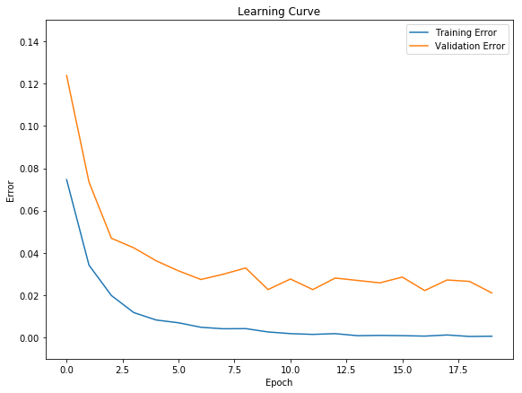

```python
plot_learning_curve(error_list)
```

## Step 3: Test a Model on New Images

### Load and Output the Images

```python
### Load the images and plot them here.
### Feel free to use as many code cells as needed.

def load_images_from_web(file_directory):
    samples = []
    labels = []
    web_images = os.listdir(file_directory)
    image_files = []
    for image_file in web_images:
        if image_file.endswith(".jpg"):
            image_files.append(image_file)

    image_files.sort()
    for image_file in image_files:
        image = mpimg.imread("{}/{}".format(file_directory, image_file))
        class_idx = int(image_file[:2])
        samples.append(image)
        labels.append(class_idx)
    return np.array(samples), np.array(labels)

# Load images found in web
x_web, y_web = load_images_from_web(web_img_path)
print("x_webshape =", x_web.shape)

#pre process them to be able use them for classifier
x_web = preproccess_data_set("data/processed_web.p", x_web, y_web, "processed_web")
print("x_webshape =", x_web.shape)
```

```
x_webshape = (5, 32, 32, 3)
Normalize images..
x_webshape = (5, 32, 32, 1)
```

### Predict the Sign Type for Each Image And Analyze Performance

```python
### Run the predictions here and use the model to output the prediction for each image.
### Make sure to pre-process the images with the same pre-processing pipeline used earlier.
### Feel free to use as many code cells as needed.
with tf.Session() as sess:
    saver.restore(sess, checkpnt_save_path_full)
    predicted_proba = np.vstack(predict(x_web))
    print('Accuracy model on web images: {}'.format(evaluate(x_web, y_web)))
```

```
INFO:tensorflow:Restoring parameters from checkpoints/my_model
Accuracy model on web images: 0.800000011920929
```

### Output Top 5 Softmax Probabilities For Each Image Found on the Web

```python
### Print out the top five softmax probabilities for the predictions on the German traffic sign images found on the web.
### Feel free to use as many code cells as needed.

for label,row in zip(y_web,predicted_proba):
    top5k = np.argsort(row)[::-1][:5]
    top5p = np.sort(row)[::-1][:5]
    img_name = class_names[label][1]
    print('Probabilities for image \'{}\' ({}):'.format(img_name, label))
    for k,p in zip(top5k,top5p):
        img_name_2 = class_names[k][1]
        print('  \'{}\' : {:.2f} '.format(img_name_2,p))
    print()
```

```
Probabilities for image 'Speed limit (20km/h)' (0):
  'Speed limit (20km/h)' : 0.95
  'Speed limit (60km/h)' : 0.04
  'Speed limit (30km/h)' : 0.00
  'Speed limit (80km/h)' : 0.00
  'End of speed limit (80km/h)' : 0.00

Probabilities for image 'Priority road' (12):
  'Priority road' : 1.00
  'No passing' : 0.00
  'Roundabout mandatory' : 0.00
  'No vehicles' : 0.00
  'Ahead only' : 0.00

Probabilities for image 'Double curve' (21):
  'Dangerous curve to the left' : 0.98
  'Slippery road' : 0.02
  'Double curve' : 0.00
  'Bicycles crossing' : 0.00
  'Road narrows on the right' : 0.00

Probabilities for image 'Bumpy road' (22):
  'Bumpy road' : 1.00
  'Bicycles crossing' : 0.00
  'Road work' : 0.00
  'Turn left ahead' : 0.00
  'Wild animals crossing' : 0.00

Probabilities for image 'Keep right' (38):
  'Keep right' : 1.00
  'Speed limit (80km/h)' : 0.00
  'Wild animals crossing' : 0.00
  'Speed limit (50km/h)' : 0.00
  'Speed limit (30km/h)' : 0.00
```